# Basics and CART

This notebook contains code from 1-basics-cart.R and the corresponding output.

## Setup

```r
library(ggplot2)
library(ggmap)
library(GGally)
library(rpart)
library(partykit)
library(pdp)
library(caret)
```

```r
load("FrankfurtMain.Rda")
set.seed(7345)
train <- sample(1:nrow(fr_immo), 0.8*nrow(fr_immo))
fr_test <- fr_immo[-train,]
fr_train <- fr_immo[train,]
```

## Some data exploration

After all packages and data have been loaded and set up, we might want to explore the training set using graphs. Here is a nice plot using `ggpairs` from the `GGally` package.

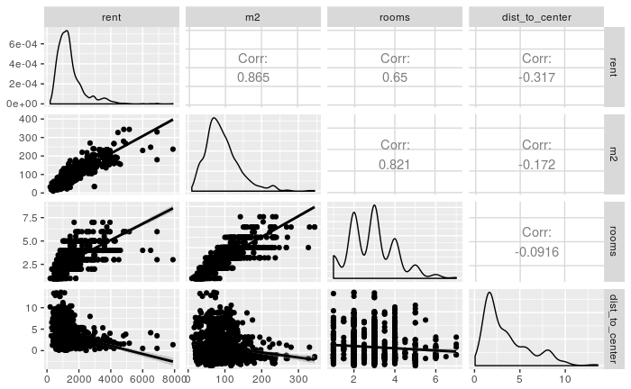

```r
ggpairs(fr_train[,c(2:4,20)], lower = list(continuous = "smooth"))
```

## Grow and prune tree

Our task is to predict rent using $m^2$, rooms, location and distance to city center as features. In order to grow a regression tree, `rpart` is used here, which follows the CART idea.

```r
set.seed(6342)
f_tree <- rpart(rent ~ m2 + rooms + lon + lat + dist_to_center, data = fr_train, cp = 0.0025)
printcp(f_tree)
```

```
Regression tree:
rpart(formula = rent ~ m2 + rooms + lon + lat + dist_to_center,
    data = fr_train, cp = 0.0025)

Variables actually used in tree construction:
[1] dist_to_center lat            m2             rooms

Root node error: 1045476156/1436 = 728047

n= 1436

          CP nsplit rel error  xerror     xstd
1  0.5410012      0   1.00000 1.00271 0.080819
2  0.1175620      1   0.45900 0.46226 0.036590
3  0.0502433      2   0.34144 0.34872 0.035577
4  0.0283914      3   0.29119 0.30796 0.030458
5  0.0168770      4   0.26280 0.28423 0.030193
6  0.0163440      5   0.24593 0.26960 0.030327
7  0.0124466      6   0.22958 0.25847 0.030314
8  0.0105879      7   0.21713 0.24899 0.027772
9  0.0104262      8   0.20655 0.24496 0.026234
10 0.0076834      9   0.19612 0.22366 0.025591
11 0.0058191     10   0.18844 0.22306 0.025665
12 0.0048263     11   0.18262 0.21686 0.027816
13 0.0036387     12   0.17779 0.20784 0.027517
14 0.0035760     13   0.17415 0.20592 0.027414
15 0.0029990     14   0.17058 0.20721 0.027653
16 0.0025733     15   0.16758 0.20968 0.027758
17 0.0025000     16   0.16500 0.20759 0.027724
```

Given the grown tree, `printcp` and `plotcp` help us to determine the best subtree, whereas `Root node error` times `xerror` gives us the estimated test error for each subtree based on cross-validation.

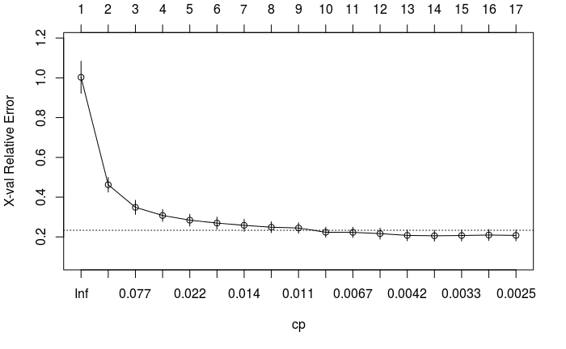

```r
plotcp(f_tree)
```

We can get the best subtree with the `prune` function, here using the one standard error rule.

```r
minx <- which.min(f_tree$cptable[,"xerror"])
minxse <- f_tree$cptable[minx,"xerror"] + f_tree$cptable[minx,"xstd"]
minse <- which.min(abs(f_tree$cptable[1:minx,"xerror"] - minxse))
mincp <- f_tree$cptable[minse,"CP"]
p_tree <- prune(f_tree, cp = mincp)
```

## Plots

An advantage of trees is that they can be easily interpreted by a simple plot. The `party` package produces nice tree plots.

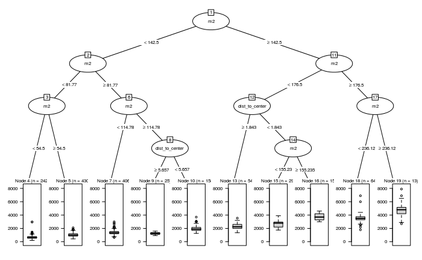

```r
prty_tree <- as.party(p_tree)
plot(prty_tree, gp = gpar(fontsize = 6))
```

If we are interested in the prediction surface of the tree, partial dependence plots using e.g. the `pdp` package can be useful.

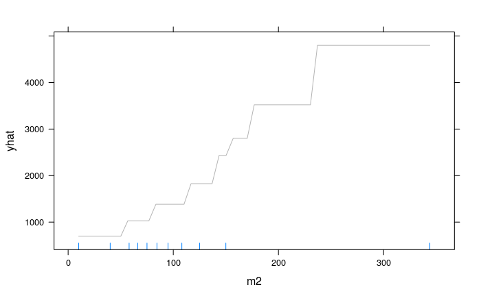

```r
pdp1 <- partial(p_tree, pred.var = "m2")
plotPartial(pdp1, rug = T, train = fr_train, alpha = 0.3)
```

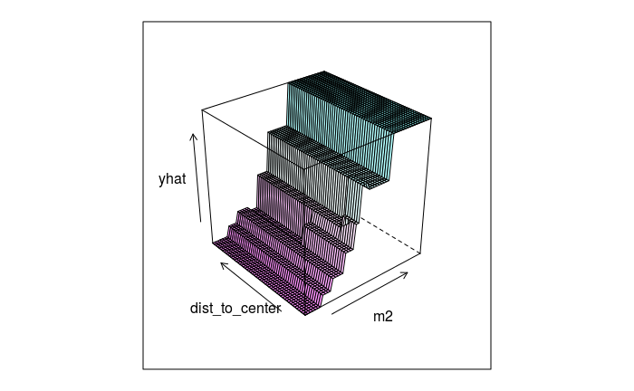

```r
pdp2 <- partial(p_tree, pred.var = c("m2", "dist_to_center"))
plotPartial(pdp2, levelplot = F, drape = T, colorkey = F, screen = list(z = 40, x = -60))
```

## Prediction

Finally, we can use the pruned tree in order to predict the outcome in the holdout (test) set. Then, `postResample` produces basic performance measures.

```r
y_tree <- predict(p_tree, newdata = fr_test)
postResample(pred = y_tree, obs = fr_test$rent)
```

```
       RMSE    Rsquared
468.2489701   0.7247648
```